# Univariate Plots

NOTE: This page has been revised for Spring 2022, but may undergo further edits.

Note: Ordinarily, learning how to download and “import” files into R/RStudio is an important part of climbing R’s steepish learning curve. To make it easier to replicate the lectures and to play with the code, here is a workaround that will load all of the individual data sets that are used in the lectures.

First, make sure that after starting RStudio, that the working directory is indeed the one created while doing Exercise 1. To reiterate, the directories are as follows:

- Windows: `C:/Users/userid/Documents/geog495/`
- Windows on a virtual machine: `R:/geog495_1/Student_Data/userid/`
- macOS: `User/userid/Documents/geog495/`

Clear the existing workspace by typing or copying the following in the `Console` pane of RStudio:

```r
# clear the current workspace
rm(list=ls(all=TRUE))
```

*WARNING: This will indeed remove everything in the current workspace.* That will be ok, unless you’re in the middle of an exercise.

# 1 Introduction

In describing or characterizing the observations of an individual variable, there are three basic properties that are of interest:

- the *location* of observations (along the number line in general (but the geographical analogy is obvious), or how large or small the values of the individual observations are)
- the *dispersion* (sometimes called scale or spread) of the observations (how spread out they are along the number line, and again the geographical analogy is obvious)
- the *distribution* of the observations (a characterization of the frequency of occurrence of different values of the variable–do some values occurs more frequently than other values?)

Univariate plots provide one way to find out about those properties (and univariate descriptive statistics provide another).

There are two basic kinds of univariate, or one-variable-at-a-time plots,

1. Enumerative plots, or plots that show every observation, and
2. Summary plots, that generalize the data into a simplified representation.

# 2 Univariate Enumerative Plots

Enumerative plots, in which all observations are shown, have the advantage of not losing any specific information–the values of the individual observations can be retrieved from the plot. The disadvantage of such plots arises when there are a large number of observations–it may be difficult to get an overall view of the properties of a variable. Enumerative plots do a fairly good job of displaying the location, dispersion and distribution of a variable, but may not allow a clear comparison of variables, one to another.

Data files for these examples: [[cities.csv]](https://github.com/mslucash/GeogDataAnalysis/tree/main/data/csv/cities.csv) [[specmap.csv]](https://github.com/mslucash/GeogDataAnalysis/tree/main/data/csv/specmap.csv)

Recall that your data folders were:

- Mac: `/Users/userid/Projects/geog495/data/`
- Windows: `C:/Users/userid/Documents/geog495/data/`
- VM (Window Virtual Machine): `R:/geog495_1/Student_Data/userid/data/`

Download the csv file from github (see path on L58). Click on the file. Hit the RAW button. Right click and hit Save As and save it with the appropriate name (cities.csv or specmap.csv)

Read the `cities.csv` file, using an explicit path:

```r
# read a .csv file
csvfile <- "C:/Users/mlucash/OneDrive - University Of Oregon/Documents/GitHub/GeogDataAnalysis/data/csv/cities.csv"
cities <- read.csv(csvfile)
```

Get some summary information about the `cities` “data frame”. The `names()` function lists the variables or attributes:

```r
# get the names of the variables
names(cities)
```

```
##  [1] "City"     "Area"     "Pop.1980" "Pop.1990" "Pop.2000" "Growth"   "Food"     "PersRoom" "Water"
## [10] "Elec"     "Phones"   "Vehicles"
```

The “structure” function (`str()`) provides a short listing of variables and few values:

```r
str(cities)
```

```
## 'data.frame':    21 obs. of  12 variables:
##  $ City    : chr  "Buenos Aires" "Dhaka" "Rio de Janeiro" "Sao Paolo" ...
##  $ Area    : num  700 100 650 800 1680 ...
##  $ Pop.1980: int  9918 3290 8789 12101 9029 11739 7268 6852 8067 9030 ...
##  $ Pop.1990: int  11448 6578 10948 18119 10867 13447 9249 8633 12223 10741 ...
##  $ Pop.2000: int  12822 11511 12162 22552 14366 17407 12508 10761 18142 12675 ...
##  $ Growth  : num  1.4 7.2 2.2 4.1 1.9 ...
##  $ Food    : int  40 63 26 50 52 55 52 47 57 60 ...
##  $ PersRoom: num  1.3 2.4 0.8 0.8 1.2 ...
##  $ Water   : int  80 60 86 100 88 95 80 91 92 51 ...
##  $ Elec    : int  91 85 98 100 90 95 84 98 78 63 ...
##  $ Phones  : int  14 2 8 16 2 4 4 4 5 2 ...
##  $ Vehicles: int  1000 600 4000 4000 308 148 200 939 588 500 ...
```

The `head()` and `tail()` functions list the first and last lines:

```r
head(cities)
```

```
##             City Area Pop.1980 Pop.1990 Pop.2000 Growth Food PersRoom Water Elec Phones Vehicles
## 1   Buenos Aires  700     9918    11448    12822    1.4   40      1.3    80   91     14     1000
## 2          Dhaka  100     3290     6578    11511    7.2   63      2.4    60   85      2      600
## 3 Rio de Janeiro  650     8789    10948    12162    2.2   26      0.8    86   98      8     4000
## 4      Sao Paolo  800    12101    18119    22552    4.1   50      0.8   100  100     16     4000
## 5        Beijing 1680     9029    10867    14366    1.9   52      1.2    88   90      2      308
## 6       Shanghai  630    11739    13447    17407    1.4   55      2.0    95   95      4      148
```

```r
tail(cities)
```

```
##           City Area Pop.1980 Pop.1990 Pop.2000 Growth Food PersRoom Water Elec Phones Vehicles
## 16 Mexico City  250    13888    15085    16190    0.8   41      1.9    92   97      6     2500
## 17       Lagos   40     4385     7742    13480    5.8   58      5.8    47   53      1      500
## 18     Karachi  353     5023     7943    11895    4.7   43      3.3    66   84      2      650
## 19      Manila   64     5966     8882    12582    4.1   38      3.0    89   93      9      510
## 20 Los Angeles 1660     9523    11456    13151    1.9   12      0.5    91   98     35     8000
## 21    New York  359    15601    16056    16645    0.3   16      0.5    99  100     56     1780
```

## 2.1 Enumerative Plots (all points shown)

“Enumerative plots” are called such because they enumerate or show every individual data point (in contrast to “summary plots”.)

Here we use the `attach()` function first. An individual variable’s “full” name is the name of the dataframe concatentated with its “short” name, with a dollar sign in between, e.g. `cities$Pop.2000`. The `attach()` function puts the data frame in the first search position and allows one to refer to a variable just by its short name (e.g. `Pop.2000`).

### 2.1.1 Index Plot/Univariate Scatter Diagram

Displays the values of a single variable for each observation using symbols, with values of the variable for each observation plotted relative to the observation number.

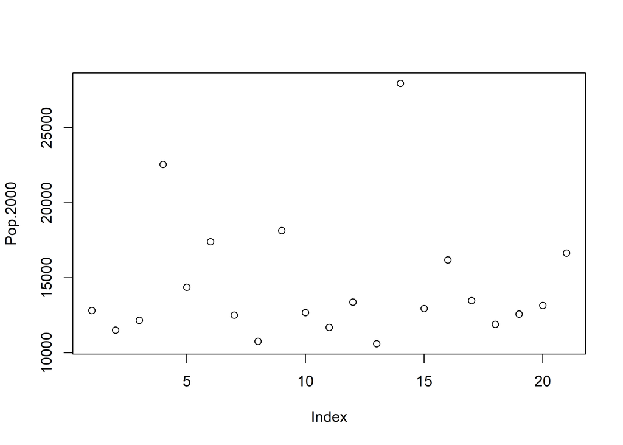

```r
# use large cities data [cities.csv], get an index plot
attach(cities)
plot(Pop.2000)
```

### 2.1.2 Y Zero High-Density Plot

Displays the values of a single variable plotted as thin vertical lines

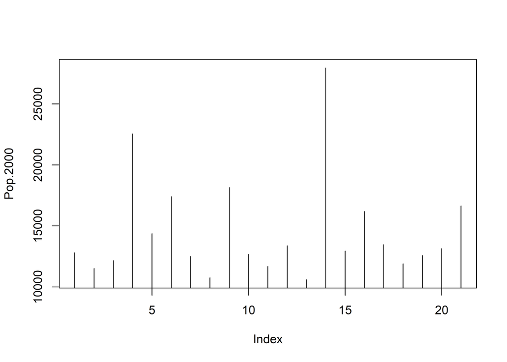

```r
# another univariate plot
plot(Pop.2000, type="h")
```

[Back to top]

## 2.2 Other plot types using `plot()`

A variety of different versions of the standard univariate plot generated with the `plot()` function can be generated using the `type=` argument.

`type = "l", "b", "o", "s", or "S"`

It’s good practice when done with a data set to detach it:

```r
# detach the cities dataframe
detach(cities)
```

### 2.2.1 Time Series Plots

When data are in some kind of order (as in time), index values contain some useful information. Read and attach the `specmap.csv` file, and then plot the delta-O18 (oxygen isotope) values.

```r
# use Specmap delta-O18 data

csvfile <- "C:/Users/mlucash/OneDrive - University Of Oregon/Documents/GitHub/GeogDataAnalysis/data/csv/specmap.csv"
specmap <- read.csv(csvfile)
```

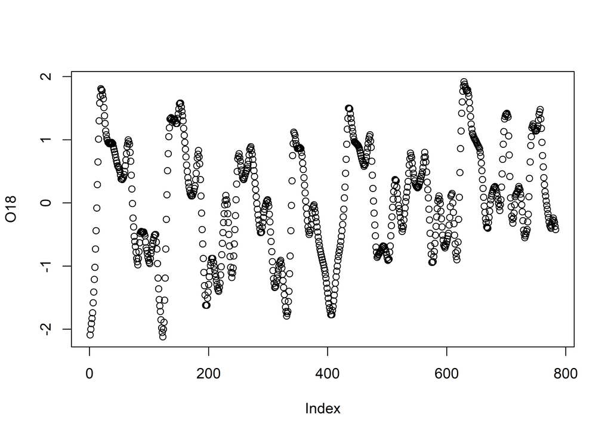

```r
# attach specmap and plot
attach(specmap)
plot(O18)
```

In this data set, the large negative values indicate warm/less-ice conditions, and so it would be more appropriate to plot the values on an inverted y-axis, using the `ylim` argument.

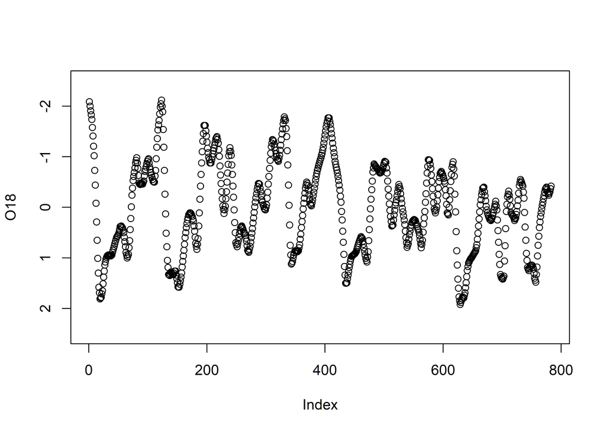

```r
# inverted y-axis
plot(O18, ylim=c(2.5,-2.5))   #  invert y-axis
```

### 2.2.2 Strip Plot/Strip Chart (univariate scatter diagram)

Displays the values of a single variable as symbols plotted along a line

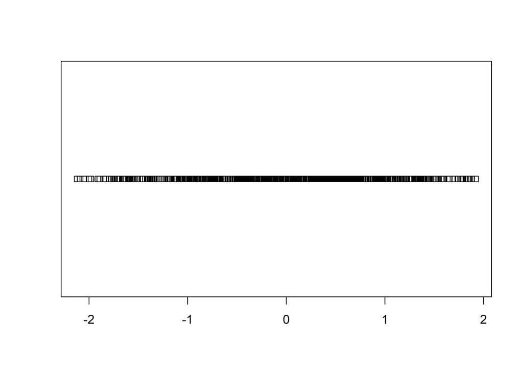

```r
# stripchart
stripchart(O18)
```

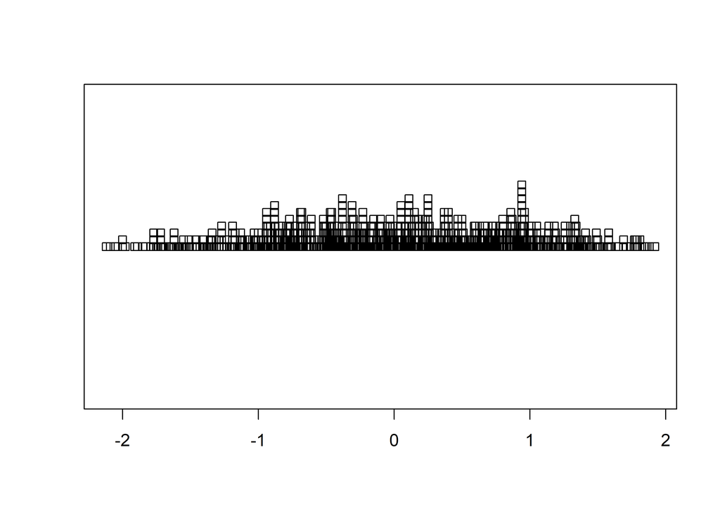

```r
stripchart(O18, method="stack")   # stack points to reduce overlap
```

```r
# detach the specmap dataframe
detach(specmap)
```

### 2.2.3 Dot Plot/Dot Chart

The Cleveland dot plot displays the values of a single variable as symbols plotted along a line, with a separate line for each observation. (Note that we reattach the data set first.)

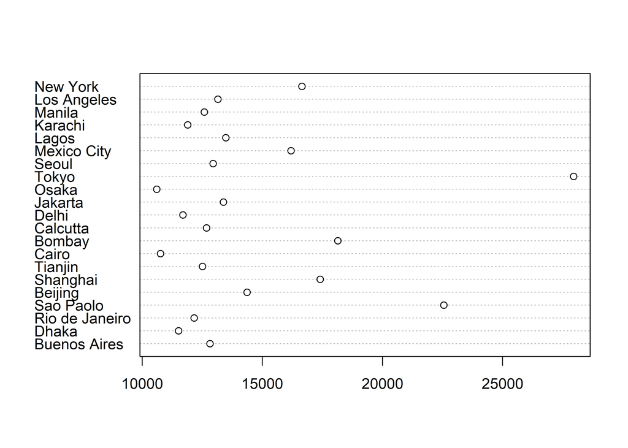

```r
# dotchart
attach(cities)
dotchart(Pop.2000, labels=City)
```

An alternative version of this plot, and the one most frequently used, can be constructed by sorting the rows of the data table. Sorting can be tricky–it is easy to completely rearrange a data set by sorting one variable and not the others. It is often better to leave the data unsorted, and to use an auxiliary variable (in this case index) to record the rank-order of the variable being plotted (in this case Pop.2000), and the explicit vector-element indexing of R to arrange the data in the right order:

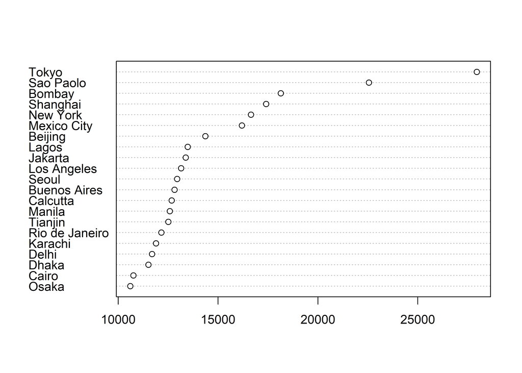

```r
# indexed (sorted) dotchart
index <- order(Pop.2000)
dotchart(Pop.2000[index], labels=City[index])
```

This example shows how to index or refer to specific values of a variable by specifying the subscripts of the observations involved (in square brackets `[`…`]`).

Once you’re done with a data set, it’s good to “detach” it to avoid conflict among variables from different data sets that might have the same name.

```r
# detach the cites dataframe
detach(cities)
```